# babette: Step by Step

Richel J.C. Bilderbeek

2018-09-19

This demo shows how to run the `babette` pipeline step by step.

The `babette` demo shows how to use `babette` at its highest level: all intermediate steps are ignored, and all intermediate files are put in a temporary folder.

```r
library(babette)
```

In all cases, this is done for a short MCMC chain length of 10K:

```r
sample_interval <- 1000
mcmc <- create_mcmc(
  chain_length = 10000,
  store_every = sample_interval
)
```

## Create a BEAST2 input file

This step is commonly done using BEAUti. With `babette`, this can be done as follows:

```r
beast2_input_file <- tempfile(fileext = ".xml")
create_beast2_input_file(
  get_babette_path("anthus_aco.fas"),
  output_filename = beast2_input_file,
  mcmc = mcmc
)
testit::assert(file.exists(beast2_input_file))
```

## Display (part of) the BEAST2 input file

```r
print(head(readLines(beast2_input_file)))
```

```
#> [1] "<?xml version=\"1.0\" encoding=\"UTF-8\" standalone=\"no\"?><beast beautitemplate='Standard' beautistatus='' namespace=\"beast.core:beast.evolution.alignment:beast.evolution.tree.coalescent:beast.core.util:beast.evolution.nuc:beast.evolution.operators:beast.evolution.sitemodel:beast.evolutio…
#> [2] ""
#> [3] ""
#> [4] "    <data"
#> [5] "id=\"anthus_aco\""
#> [6] "name=\"alignment\">"
```

This file can both be loaded by BEAUti and be used by BEAST2.

The file can be checked if it is indeed a valid input file:

```r
testit::assert(is_beast2_input_file(beast2_input_file))
```

## Run MCMC

This step is commonly done using BEAST2 from the command-line or using its GUI. With `babette`, this can be done as follows:

```r
log_filename <- tempfile(fileext = ".log")
trees_filename <- tempfile(fileext = "trees")
state_filename <- tempfile(fileext = ".xml.state")
run_beast2(
  input_filename = beast2_input_file,
  output_log_filename = log_filename,
  output_trees_filenames = trees_filename,
  output_state_filename = state_filename
)
```

[output not shown]

[output cut: 96 more lines]

```r
testit::assert(file.exists(log_filename))
testit::assert(file.exists(trees_filename))
testit::assert(file.exists(state_filename))
```

## Display (part of) the BEAST2 output files

The `.log` file contains the model parameters and parameter estimates:

```r
print(head(readLines(log_filename)))
```

```
#> [1] "#"
#> [2] "#model:"
#> [3] "#"
#> [4] "#<?xml version=\"1.0\" encoding=\"UTF-8\" standalone=\"no\"?><input id=\"posterior\" spec=\"beast.core.util.CompoundDistribution\">"
#> [5] "#    <distribution id=\"prior\" spec=\"beast.core.util.CompoundDistribution\">"
#> [6] "#        <distribution id=\"YuleModel.t:anthus_aco\" spec=\"beast.evolution.speciation.YuleModel\">"
```

```r
print(tail(readLines(log_filename)))
```

```
#> [1] "5000\t-1765.8743175785276\t-1859.825501859856\t93.95118428132844\t-1859.825501859856\t0.01615439048692105\t93.95118428132844\t299.0379614687076"
#> [2] "6000\t-1764.6333554238995\t-1862.774780451527\t98.14142502762743\t-1862.774780451527\t0.013123645244827665\t98.14142502762743\t275.98101071253"
#> [3] "7000\t-1761.5037909456032\t-1860.6070792907797\t99.10328834517644\t-1860.6070792907797\t0.010449249338930572\t99.10328834517644\t336.19377804117755"
#> [4] "8000\t-1771.4886229226447\t-1865.036433839036\t93.54781091639128\t-1865.036433839036\t0.012884954140922045\t93.54781091639128\t234.5861341220454"
#> [5] "9000\t-1769.6035230481361\t-1859.9147689533\t90.31124590516372\t-1859.9147689533\t0.0126025547138091\t90.31124590516372\t343.91490504245"
#> [6] "10000\t-1758.5472510462366\t-1855.9919721142805\t97.44472106804388\t-1855.9919721142805\t0.012422390334873114\t97.44472106804388\t282.38244105663676"
```

The `.trees` file contains the alignment, taxa and posterior trees:

```r
print(head(readLines(trees_filename)))
print(tail(readLines(trees_filename)))
```

[output not shown]

The `.xml.state` file contains the final state of the MCMC run and the MCMC operator acceptances thus far:

```r
print(head(readLines(state_filename)))
```

```
#> [1] "<itsabeastystatewerein version='2.0' sample='10000'>"
#> [2] "<statenode id='Tree.t:anthus_aco'>(((((((0:1.4556681283166005E-4,(2:1.0583716968531007E-4,16:1.0583716968531007E-4)22:3.972964314634998E-5)34:3.3417636708589905E-4,4:4.7974317991755907E-4)36:5.529843498626608E-4,10:0.00103272752978022)24:0.003077815117896398,(8:4.614076878374552E-5,19:4.6140…
#> [3] "<statenode id='birthRate.t:anthus_aco'>birthRate.t:anthus_aco[1 1] (-Infinity,Infinity): 282.38244105663676 </statenode>"
#> [4] "</itsabeastystatewerein>"
#> [5] "<!--"
#> [6] "{\"operators\":["
```

```r
print(tail(readLines(state_filename)))
```

```
#> [1] "{\"id\":\"YuleModelSubtreeSlide.t:anthus_aco\",\"p\":1,\"accept\":6,\"reject\":2011,\"acceptFC\":0,\"rejectFC\":0,\"rejectIv\":990,\"rejectOp\":990},"
#> [2] "{\"id\":\"YuleModelNarrow.t:anthus_aco\",\"p\":\"NaN\",\"accept\":842,\"reject\":1091,\"acceptFC\":0,\"rejectFC\":0,\"rejectIv\":0,\"rejectOp\":0},"
#> [3] "{\"id\":\"YuleModelWide.t:anthus_aco\",\"p\":\"NaN\",\"accept\":25,\"reject\":365,\"acceptFC\":0,\"rejectFC\":0,\"rejectIv\":182,\"rejectOp\":182},"
#> [4] "{\"id\":\"YuleModelWilsonBalding.t:anthus_aco\",\"p\":\"NaN\",\"accept\":32,\"reject\":413,\"acceptFC\":0,\"rejectFC\":0,\"rejectIv\":78,\"rejectOp\":78}"
#> [5] "]}"
#> [6] "-->"
```

## Parse output

This step is commonly done using Tracer. With `babette`, this can be done as follows.

Parsing `.log` file to obtain the parameter estimates:

```r
knitr::kable(head(parse_beast_log(log_filename)))
```

| Sample | posterior | likelihood | prior | treeLikelihood | TreeHeight | YuleModel | birthRate |
| --- | --- | --- | --- | --- | --- | --- | --- |
| 0 | -7935.012 | -7926.491 | -8.521204 | -7926.491 | 1.9102133 | -8.521204 | 1.000000 |
| 1000 | -1983.798 | -2015.910 | 32.112308 | -2015.910 | 0.2073561 | 32.112308 | 5.416934 |
| 2000 | -1783.659 | -1865.827 | 82.167655 | -1865.827 | 0.0246991 | 82.167655 | 94.913407 |
| 3000 | -1765.856 | -1858.242 | 92.386415 | -1858.242 | 0.0133847 | 92.386415 | 181.456430 |
| 4000 | -1763.058 | -1860.894 | 97.836925 | -1860.894 | 0.0115499 | 97.836925 | 333.842581 |
| 5000 | -1765.874 | -1859.826 | 93.951184 | -1859.826 | 0.0161544 | 93.951184 | 299.037961 |

Parsing `.trees` file to obtain the posterior phylogenies:

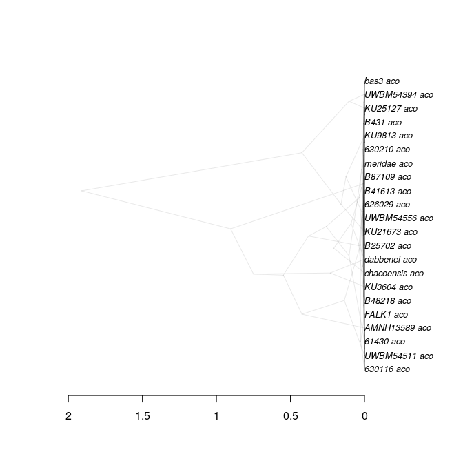

```r
plot_densitree(parse_beast_trees(trees_filename))
```

Parsing `.xml.state` file to obtain the MCMC operator acceptances:

```r
knitr::kable(head(parse_beast_state_operators(state_filename)))
```

| operator | p | accept | reject | acceptFC | rejectFC | rejectIv | rejectOp |
| --- | --- | --- | --- | --- | --- | --- | --- |
| YuleBirthRateScaler.t | 0.75 | 298 | 110 | 0 | 0 | 0 | 0 |
| YuleModelTreeScaler.t | 0.50 | 96 | 271 | 0 | 0 | 0 | 0 |
| YuleModelTreeRootScaler.t | 0.50 | 107 | 308 | 0 | 0 | 34 | 34 |
| YuleModelUniformOperator.t | NaN | 2346 | 1680 | 0 | 0 | 0 | 0 |
| YuleModelSubtreeSlide.t | 1.00 | 6 | 2011 | 0 | 0 | 990 | 990 |
| YuleModelNarrow.t | NaN | 842 | 1091 | 0 | 0 | 0 | 0 |